# Lab-4

```python
# Following code given in directions
%matplotlib inline
import numpy as np
import matplotlib
import matplotlib.pyplot as plt
import scipy
from scipy import stats
import h5py

#this sets the size of the plot to something useful
plt.rcParams["figure.figsize"] = (20,15)
```

```python
# Get data from file
hf = h5py.File('gammaray_lab4.h5', 'r')
print(hf.keys())
data = np.array(hf.get('data'))
print(data[:,0])
```

```
<KeysViewHDF5 ['data']>
[9.40680016e+08 3.15000000e+02 4.50000000e+01 1.00000000e+01]
```

```python
hf.close()
```

## Problem 1

#### 1) Download the data from the course website (gammaray_lab4.h5), and import it into your working environment. The data has 4 columns and more than 25 million rows. The columns are time (in gps seconds), Solar phase (deg) showing the position of the sun relative to the orbit, Earth longitude (deg) giving the position of the spacecraft relative to the ground, and particle counts. Make a few plots, generally exploring your data and making sure you understand it. Give a high level description of the data features you see. Specifically comment on whether you see signal contamination in your data, and how you plan to build a background pdf().

```python
print(np.shape(data))
```

```
(4, 25920001)
```

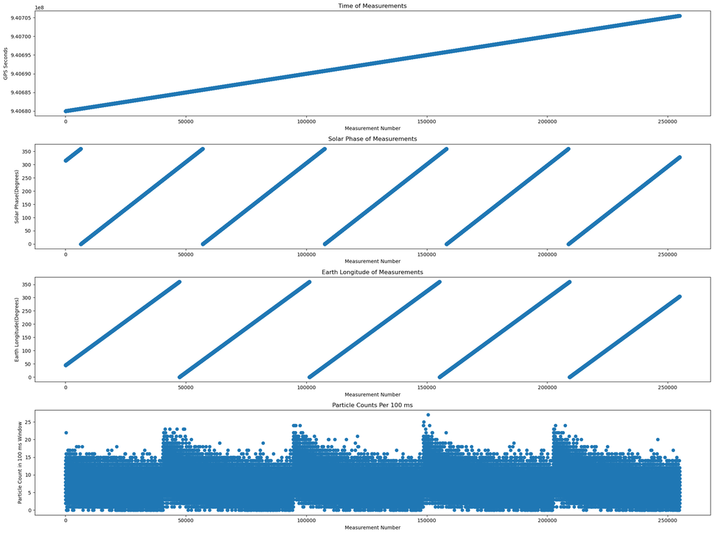

```python
# Overview of the different graphs' first segment of data points
num_points = 255000

fig, ((ax1), (ax2), (ax3), (ax4)) = plt.subplots(4, 1)
ax1.scatter(np.linspace(0,num_points,num_points),data[0,0:num_points])
ax2.scatter(np.linspace(0,num_points,num_points),data[1,0:num_points])
ax3.scatter(np.linspace(0,num_points,num_points),data[2,0:num_points])
ax4.scatter(np.linspace(0,num_points,num_points),data[3,0:num_points])
ax1.set_title("Time of Measurements")
ax1.set_xlabel("Measurement Number")
ax1.set_ylabel("GPS Seconds")
ax2.set_title("Solar Phase of Measurements")
ax2.set_xlabel("Measurement Number")
ax2.set_ylabel("Solar Phase(Degrees)")
ax3.set_title("Earth Longitude of Measurements")
ax3.set_xlabel("Measurement Number")
ax3.set_ylabel("Earth Longitude(Degrees)")
ax4.set_title("Particle Counts Per 100 ms")
ax4.set_xlabel("Measurement Number")
ax4.set_ylabel("Particle Count in 100 ms Window")
fig.tight_layout()
fig.show()
```

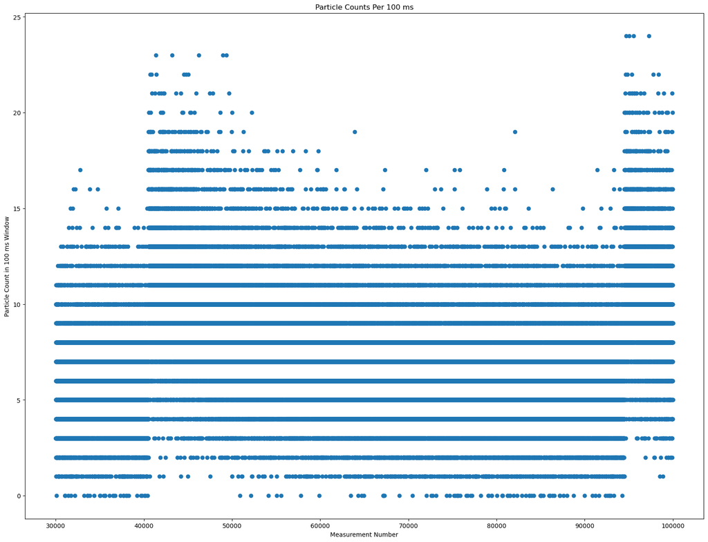

```python
# "Zoomed in" view of a segment of particle count data
start_point = 30000
num_points = 70000
plt.scatter(np.linspace(start_point,start_point+num_points,num_points),data[3,start_point:start_point+num_points])
plt.title("Particle Counts Per 100 ms")
plt.xlabel("Measurement Number")
plt.ylabel("Particle Count in 100 ms Window")
```

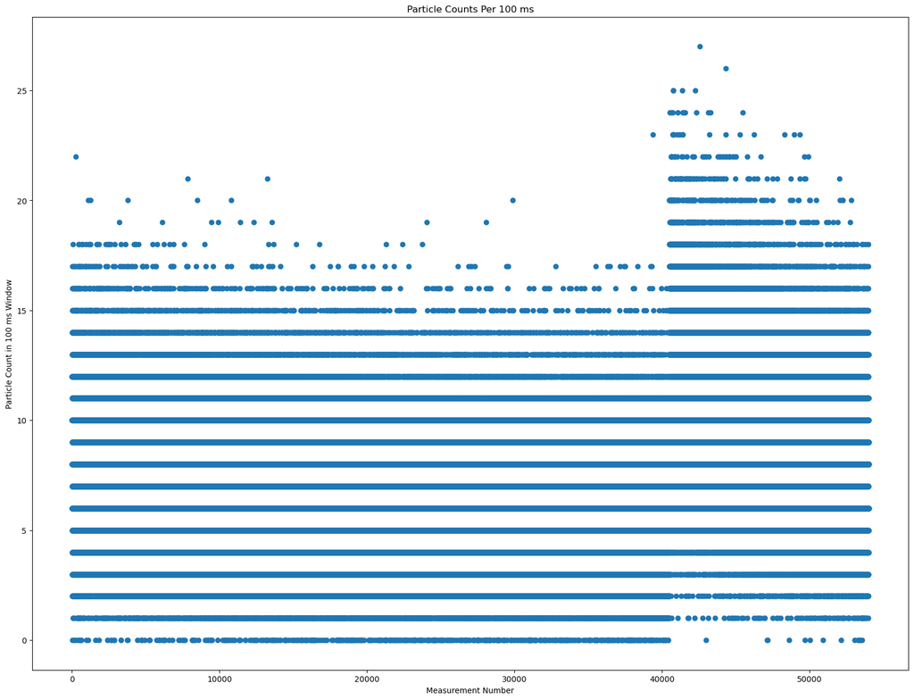

```python
# Folded Data
start_point = 0
num_points = 400000
plt.scatter(np.linspace(start_point,start_point+num_points,num_points)%54000,data[3,start_point:start_point+num_points])
plt.title("Particle Counts Per 100 ms")
plt.xlabel("Measurement Number")
plt.ylabel("Particle Count in 100 ms Window")
```

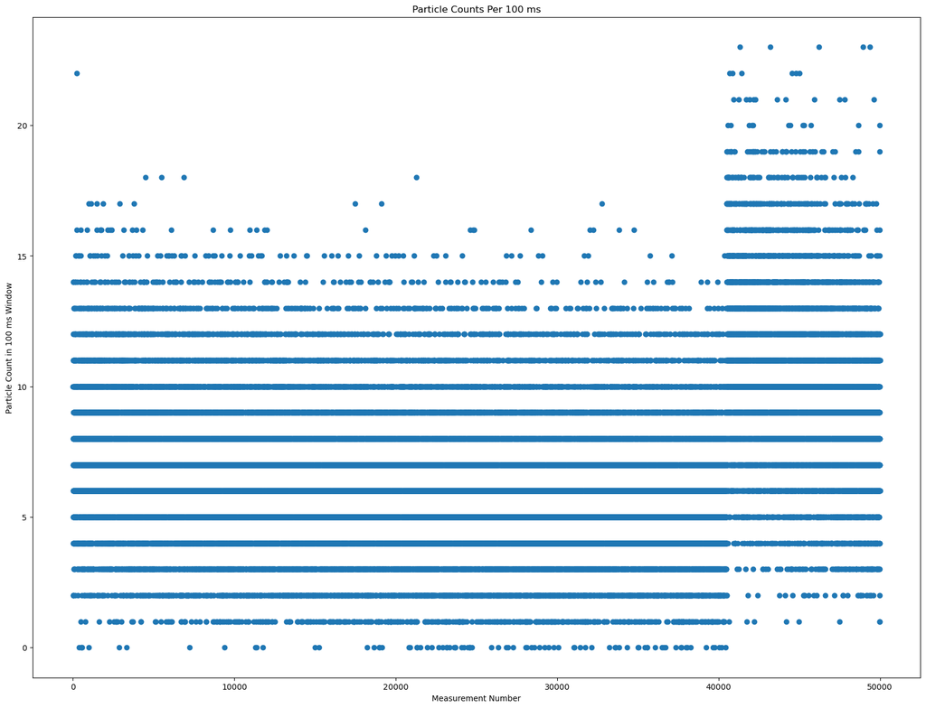

```python
# Normal Data to compare to folded data above
start_point = 0
num_points = 50000
plt.scatter(np.linspace(start_point,start_point+num_points,num_points),data[3,start_point:start_point+num_points])
plt.title("Particle Counts Per 100 ms")
plt.xlabel("Measurement Number")
plt.ylabel("Particle Count in 100 ms Window")
```

Time, solar phase (degrees), and Earth's longitudinal (in degrees) all increase at a constant rate with periodic resets down to 0 for solar phase and Earth longitudinal (which makes sense as periodic measurements are being taken by a satellite orbiting at a constant velocity). The number of particles per 100 ms has a lot of signal contamination and additionally seems to jump upwards every so often (approximately avery 54,000 data points). The background pdf might have to be built with signals nearby the point we're curious about, or generated from a bunch of folded sections of the data. The background pdf also might be approximatable through a Poisson distribution (since it's a bunch of independent events) changing as a decaying exponential folded over a factor of 54,000.

#### Part 2) The background is not consistent across the dataset. Find and describe as accurately as you can how the background changes.

The background jumps up by around 7-8 particles per 100ms then slowly decreases exponentially-ish to where it began over the course of almost 50,000 measurements

#### Part 3) Create a model for the background that includes time dependence, and explicitly compare your model to the data. How good is your model of the background?

My model (shown below) appears decently similar to the actual data (shown below my model), as both have a repeating cycle starting at around 42,000 every 54,000 data points where the data jumps up to mostly range between 2 and 22, then decays to mostly range between 14 and 0 before repeating the cycle once again. One problem with my model is that it tends to have a few more outliers than the actual data, and so it might be more difficult to identify outliers in the actual data.

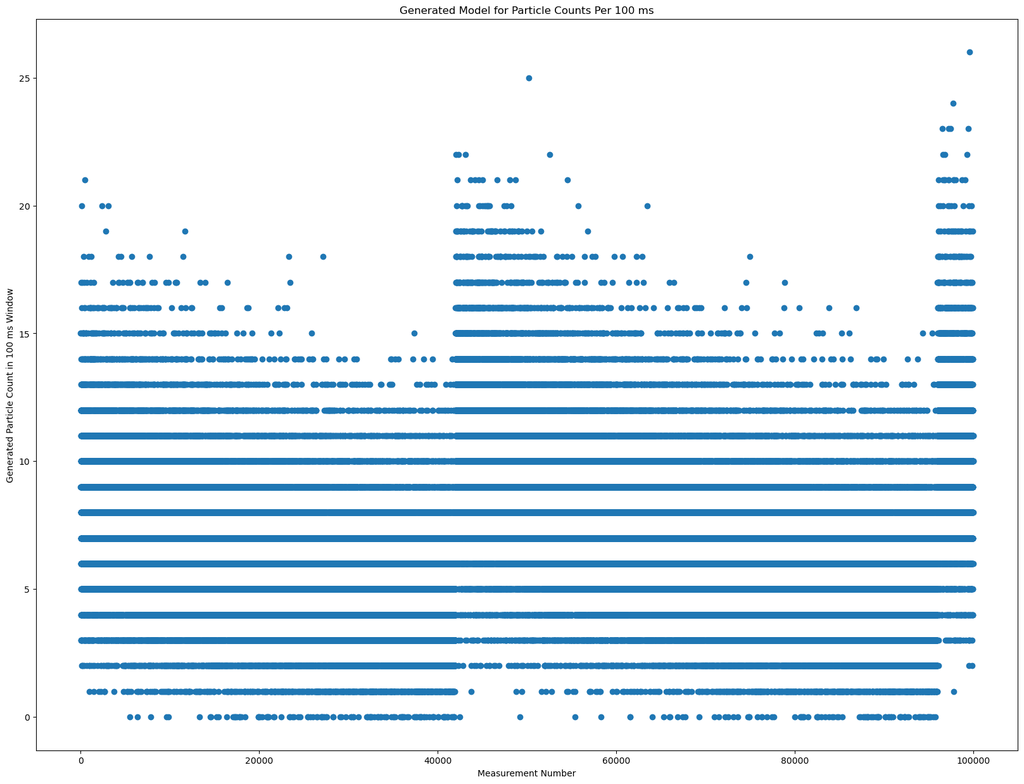

```python
# Generated Model Code
from scipy.stats import poisson

start_point = 0
num_points = 100000

x = np.linspace(start_point,start_point+num_points,num_points)
mu = 4 + 7 ** (1-(((x+12000)%54000)/54000))
pois = poisson.rvs(mu, size=num_points, loc = 0)

plt.scatter(np.linspace(start_point,start_point+num_points,num_points),pois[start_point:start_point+num_points])
plt.title("Generated Model for Particle Counts Per 100 ms")
plt.xlabel("Measurement Number")
plt.ylabel("Generated Particle Count in 100 ms Window")
```

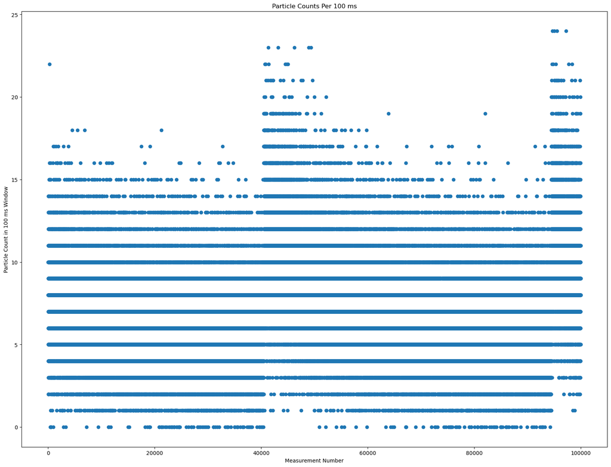

```python
# "Actual" Data Code
start_point = 0
num_points = 100000
plt.scatter(np.linspace(start_point,start_point+num_points,num_points),data[3,start_point:start_point+num_points])
plt.title("Particle Counts Per 100 ms")
plt.xlabel("Measurement Number")
plt.ylabel("Particle Count in 100 ms Window")
```

#### Part 4) Because the background varies, your discovery sensitivity threshold (how many particles you would need to see) also varies. What is the '5-sigma' threshold for a 100 millisecond GRB at different times?

```python
# Calculations for the discovery sensitivity threshold in number of particles
from scipy.stats import norm

start_point = 0
num_points = 100000

x = np.linspace(start_point,start_point+num_points,num_points)
mu_arr = 4 + 7 ** (1-(((x+12000)%54000)/54000))

print("Following 5-sigma threshold units are in number of particles")
print("5-sigma threshold for a 100ms GRB at 0th measurement: " + str(poisson.ppf(norm.cdf(5), mu = mu_arr[0])))
print("5-sigma threshold for a 100ms GRB at 10000th measurement: " + str(poisson.ppf(norm.cdf(5), mu = mu_arr[10000])))
print("5-sigma threshold for a 100ms GRB at 20000th measurement: " + str(poisson.ppf(norm.cdf(5), mu = mu_arr[20000])))
print("5-sigma threshold for a 100ms GRB at 30000th measurement: " + str(poisson.ppf(norm.cdf(5), mu = mu_arr[30000])))
print("5-sigma threshold for a 100ms GRB at 40000th measurement: " + str(poisson.ppf(norm.cdf(5), mu = mu_arr[40000])))
print("5-sigma threshold for a 100ms GRB at 50000th measurement: " + str(poisson.ppf(norm.cdf(5), mu = mu_arr[50000])))
```

```
Following 5-sigma threshold units are in number of particles
5-sigma threshold for a 100ms GRB at 0th measurement: 27.0
5-sigma threshold for a 100ms GRB at 10000th measurement: 24.0
5-sigma threshold for a 100ms GRB at 20000th measurement: 22.0
5-sigma threshold for a 100ms GRB at 30000th measurement: 21.0
5-sigma threshold for a 100ms GRB at 40000th measurement: 20.0
5-sigma threshold for a 100ms GRB at 50000th measurement: 28.0
```

## Problem 2

#### Part 1) Dowload the data from images.h5. This is a stack of 10 square images, each 200 pixels on a side.

Note: Doing faintest stars, not transient

```python
# Open file and get images out of it
hf = h5py.File('images.h5', 'r')
print(hf.keys())
img1 = np.array(hf.get('image1'))
img_data = np.array(hf.get('imagestack'))
print(np.shape(img1))
print(np.shape(img_data))
hf.close()
```

```
<KeysViewHDF5 ['image1', 'imagestack']>
(200, 200)
(200, 200, 10)
```

#### Part 2) Explore the data. Is there signal contamination? Is the background time dependent? Is it consistent spatially? Develop a plan to calculate your background pdf().

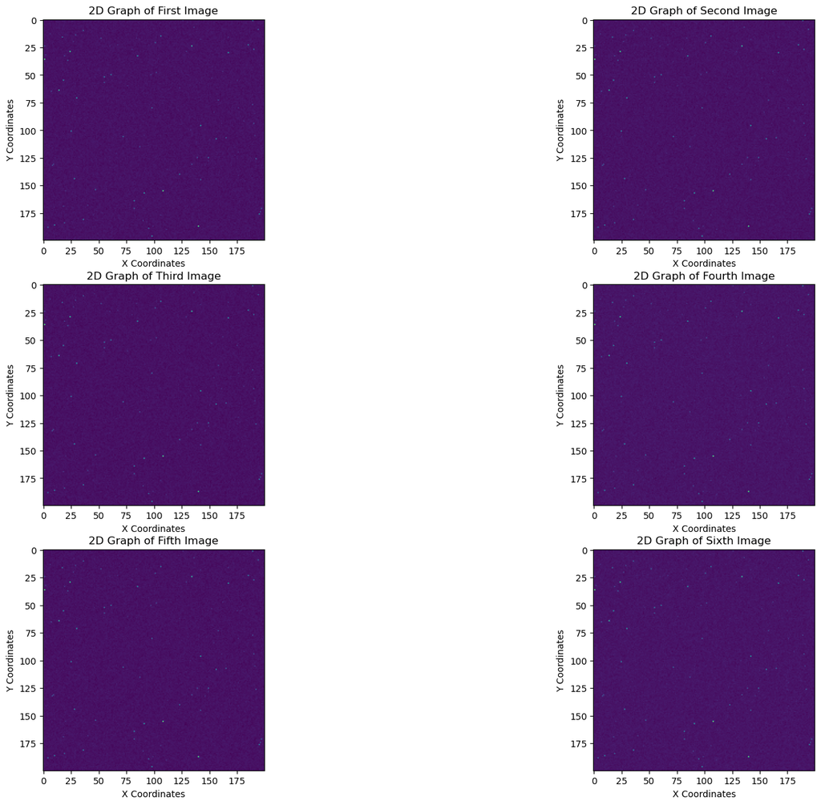

```python
# Exploring data visually
fig, ((ax1, ax2), (ax3, ax4), (ax5, ax6)) = plt.subplots(3, 2)

ax1.imshow(img_data[:,:,0])
ax2.imshow(img_data[:,:,1])
ax3.imshow(img_data[:,:,2])
ax4.imshow(img_data[:,:,3])
ax5.imshow(img_data[:,:,4])
ax6.imshow(img_data[:,:,5])

ax1.set_title("2D Graph of First Image")
ax2.set_title("2D Graph of Second Image")
ax3.set_title("2D Graph of Third Image")
ax4.set_title("2D Graph of Fourth Image")
ax5.set_title("2D Graph of Fifth Image")
ax6.set_title("2D Graph of Sixth Image")

ax1.set_xlabel("X Coordinates")
ax1.set_ylabel("Y Coordinates")
ax2.set_xlabel("X Coordinates")
ax2.set_ylabel("Y Coordinates")
ax3.set_xlabel("X Coordinates")
ax3.set_ylabel("Y Coordinates")
ax4.set_xlabel("X Coordinates")
ax4.set_ylabel("Y Coordinates")
ax5.set_xlabel("X Coordinates")
ax5.set_ylabel("Y Coordinates")
ax6.set_xlabel("X Coordinates")
ax6.set_ylabel("Y Coordinates")
plt.show()
```

```python
print("Max of first row (visually with 0 stars) is: " + str(max(img_data[0,:,0])))
print("Min of first row (visually with 0 stars) is: " + str(min(img_data[0,:,0])))
print("Second row looks like it has a star")
print("Max of third row (visually with 0 stars) is: " + str(max(img_data[2,:,0])))
print("Min of third row (visually with 0 stars) is: " + str(min(img_data[2,:,0])))

print("Max of all first rows (visually with 0 stars) is: " + str(max(img_data[0,:,:].flatten())))
print("Min of all first rows (visually with 0 stars) is: " + str(min(img_data[0,:,:].flatten())))
```

```
Max of first row (visually with 0 stars) is: 1.556945298740705
Min of first row (visually with 0 stars) is: -1.2981278361858595
Second row looks like it has a star
Max of third row (visually with 0 stars) is: 1.7488277298671364
Min of third row (visually with 0 stars) is: -1.4804323901223608
Max of all first rows (visually with 0 stars) is: 1.9955820607564105
Min of all first rows (visually with 0 stars) is: -1.6994599247013218
```

```
<function matplotlib.pyplot.show(close=None, block=None)>
```

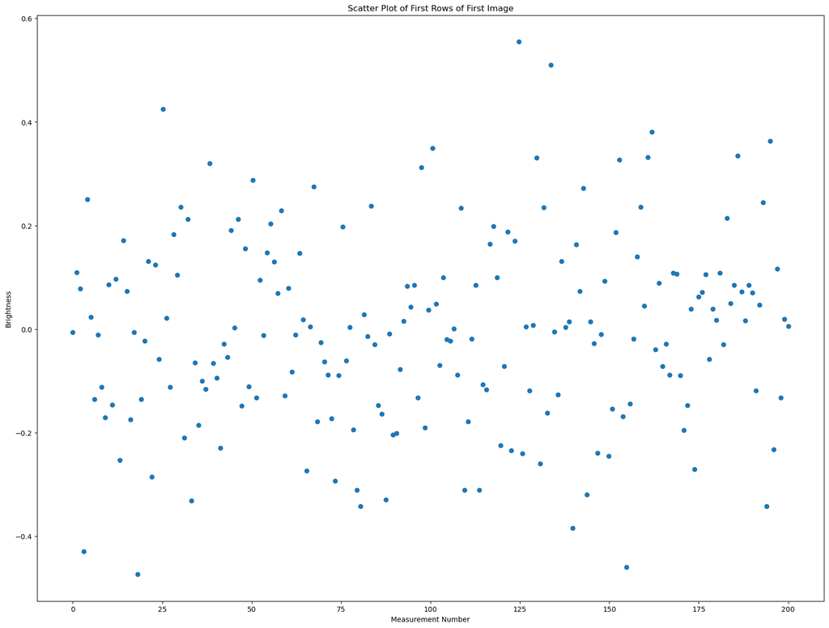

```python
#background_data = img_data[0,:,:].flatten()
avg_images_first_row = np.mean(img_data[0,:,:],axis=1)
plt.scatter(np.linspace(0,200,200),avg_images_first_row)
plt.title("Scatter Plot of First Rows of First Image")
plt.xlabel("Measurement Number")
plt.ylabel("Brightness")
plt.show
```

When averaged over all the images, data seems approximately Gaussian with a range of approximately -0.5 to 0.5, which matches the standard deviation calculated in the following code block.

```python
std_dev = np.std(avg_images_first_row)
print("Standard deviation: " + str(std_dev))
```

```
Standard deviation: 0.18448489973634996
```

Background does not seem particularly time dependent and seems to be consistent spatially, so I feel comfortable using the standard deviation calculated previously and assuming the background is Gaussian.

#### Part 3) Using your background distribution, hunt for your signal (either faint stars, or a transient). Describe what you find.

Plan is to average the images together and then find locations that are consistently over a 5-sigma value. This will catch brighter stars, but if wanted I can filter them out by discarding locations that are consistently over a 20 or 30 sigma value.

```python
# Start with all 10 images averaged into a single 200 by 200 array
avg_images = np.mean(img_data,axis=2)
avg_images.reshape((200,200))

# Finds where average of images is over 5 standard deviations away from mean
bright_index = np.where(avg_images > std_dev * 5)

# Gets values where over 5 standard deviations away from mean
bright_val = avg_images[bright_index]

# Gets indices where under 30 standard deviations away from mean
# as well as over 5 standard deviations away from mean,
# ie removes bright stars to only leave faint stars
faint_index = np.where(bright_val < std_dev * 30)

# Gets values where under 30 standard deviations away from mean
# as well as over 5 standard deviations away from mean
faint_val = bright_val[faint_index]

# Gets indices of faint stars in original averaged array
faint_x = bright_index[0][faint_index]
faint_y = bright_index[1][faint_index]
faint_true_coordinates = np.append(faint_x, faint_y).reshape(2,56)

print("Number of faint stars: " + str(np.shape(faint_val)))
print("Values of faint stars: " + str(faint_val))

print("Size of array of faint star coordinates: " + str(np.shape(faint_true_coordinates)))
print("Values of faint star coordinates: " + str(faint_true_coordinates))
```

```
Number of faint stars: (56,)
Values of faint stars: [5.18528502 2.62113274 2.45479969 4.59746669 4.64305218 4.53298393
 4.81145898 1.62188606 4.44008547 3.57731519 0.95460714 4.46168773
 1.70028085 5.23959435 2.23169475 4.9121505  4.98909862 1.43724732
 3.89034397 1.59349946 3.95443239 5.02962021 4.53036217 2.59587366
 3.94525054 3.34110753 3.45649264 3.00379266 2.90921489 1.8531823
 2.60307169 4.09467384 2.64015726 1.97617754 2.37057049 1.87409422
 3.9340624  3.84752637 2.81831612 1.86169011 2.08905546 1.39745996
 3.26255489 1.37173531 2.17703433 1.16175963 4.41436961 1.20467324
 1.34457309 2.34017901 2.49934788 5.19402663 1.03194616 4.74974425
 4.12213027 1.78691994]
Size of array of faint star coordinates: (2, 56)
Values of faint star coordinates: [[  1   4   8  13  16  17  18  21  23  24  25  27  38  47  52  53  55  55
   60  61  62  80  84  85  92  94 100 105 106 108 109 120 121 123 126 127
  128 132 134 136 137 139 141 142 146 152 155 163 164 175 177 177 186 187
  190 199]
 [126 105  46   6 167  84 142 106  67  60 143  80  72 162  46 152 175 178
   76  54 123 176 154 191 181 161 133  91  25  75 150 176  66 173 175  32
  149 146  60 112 183 138 176 107 182 116  20 112  36  53  45 106 164  99
  111  87]]
```

My code found 56 places between 5 and 30 sigma away from the background distribution as shown above, along with their coordinates also shown above. This signifies approximately 56 faint stars in the data, along with their locations in the night sky.

#### Part 4) You and your lab partner had different pdf(), but were using the same data. Explore why this is.

We were attempting to find different things from the data, ie I was looking to find consistent sources of light while my lab partner was trying to find a single bright transient in the data, so I averaged the images to better be able to see consistent sources while my lab partner likely tried to find differences between images to isolate the blip and distinguish it from more consistent sources of light.